# 📝 Aplicación de HDBSCAN en gestantes de Lima Norte 👩👩👩

Comparación entre DBSCAN y HDBSCAN

Edgar De la Cruz Bustamante, Corina Navarrete Macedo, Jean Paul Villanueva Soto

Última edición: 17 Julio 2025

# 1 🚀 Introducción

En escenarios del mundo real, los conjuntos de datos suelen presentar una estructura compleja que desafía los supuestos de muchos algoritmos clásicos de agrupamiento. Es razonable esperar que los clústeres presentes tengan formas y tamaños arbitrarios, que varíen en densidad local, y que además existan puntos atípicos o de ruido dispersos entre ellos. Esta combinación de características hace que los métodos tradicionales de clustering, como K-means o clustering jerárquico aglomerativo con distancias euclidianas, resulten insuficientes, ya que tienden a generar clústeres esféricos, homogéneos y sensibles al ruido.

DBSCAN (Density-Based Spatial Clustering of Applications with Noise) fue una respuesta poderosa a estas limitaciones, al introducir un criterio de agrupamiento basado en densidad. Sin embargo, DBSCAN asume que la densidad local es aproximadamente uniforme en todo el espacio, lo cual es controlado por su parámetro eps. Esta suposición global no siempre se ajusta a la realidad: cuando los clústeres tienen densidades variables, el uso de un único valor de eps puede generar resultados erróneos, como la fusión de clústeres distintos o la omisión de agrupaciones válidas. Para superar esta limitación, surge HDBSCAN (Hierarchical DBSCAN), un algoritmo que extiende DBSCAN y combina la robustez del agrupamiento por densidad con una estructura jerárquica y una estrategia automatizada de selección de clústeres basada en su estabilidad.

HDBSCAN fue propuesto por Campello, Moulavi y Sander en el año 2013, y formalizado computacionalmente en 2015 como una extensión jerárquica y robusta de DBSCAN. Entre sus principales ventajas se encuentran su capacidad para detectar clústeres de densidad variable, identificar formas arbitrarias, y clasificar puntos de ruido sin intervención manual. Además, no requiere definir un valor fijo de eps, sino que utiliza una jerarquía basada en densidad para extraer automáticamente los clústeres más estables. Por otro lado, entre sus desventajas se puede mencionar que es computacionalmente más costoso que DBSCAN, especialmente en conjuntos de datos muy grandes, y que la interpretación de sus parámetros (como min_cluster_size y min_samples) puede no ser trivial en aplicaciones específicas. Aun así, HDBSCAN se ha consolidado como una de las alternativas más flexibles y efectivas para el clustering no supervisado en contextos reales complejos.

En la figura 1, se muestra cómo el algoritmo DBSCAN asume densidad uniforme en los datos, controlada por el parámetro eps. Cuando se aplica a un conjunto con forma no convexa o densidad variable, puede unir erróneamente clústeres distintos o fragmentar clústeres verdaderos, ya que la misma configuración no se adapta bien a regiones con distintas distribuciones de puntos.

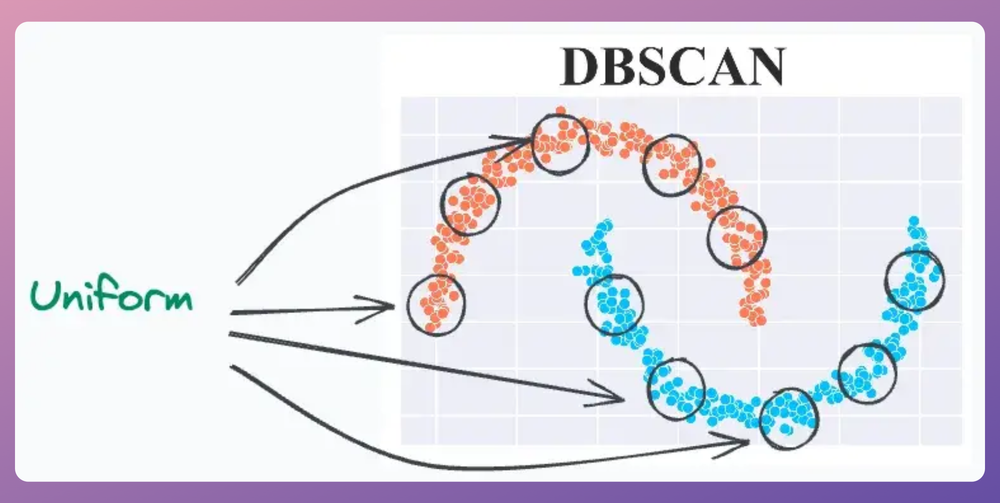

Figura 1. Supuesto de densidad uniforme en DBSCAN y sus efectos en formas complejas.

Fuente: https://blog.dailydoseofds.com/p/hdbscan-vs-dbscan

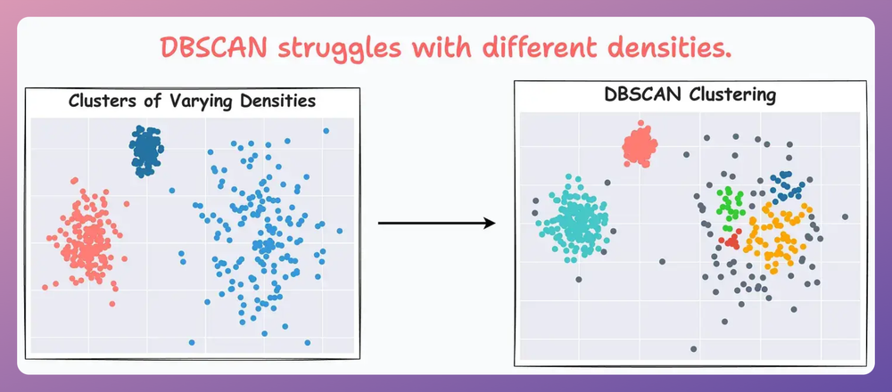

Figura 2. Limitaciones de DBSCAN al aplicar un único umbral de densidad.

Fuente: https://blog.dailydoseofds.com/p/hdbscan-vs-dbscan

En la figura 3, se ilustra cómo HDBSCAN logra detectar correctamente los clústeres con distintas densidades sin necesidad de ajustar manualmente un umbral global. Gracias a su análisis jerárquico de densidad y selección basada en estabilidad, puede adaptarse a la estructura interna de los datos y diferenciar agrupaciones válidas incluso cuando DBSCAN falla.

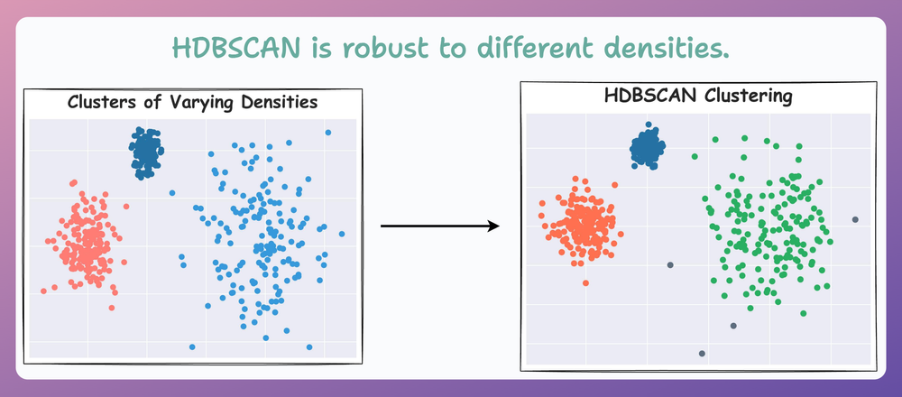

Figura 3. Agrupamiento correcto de HDBSCAN en presencia de densidades variables.

Fuente: https://blog.dailydoseofds.com/p/hdbscan-vs-dbscan

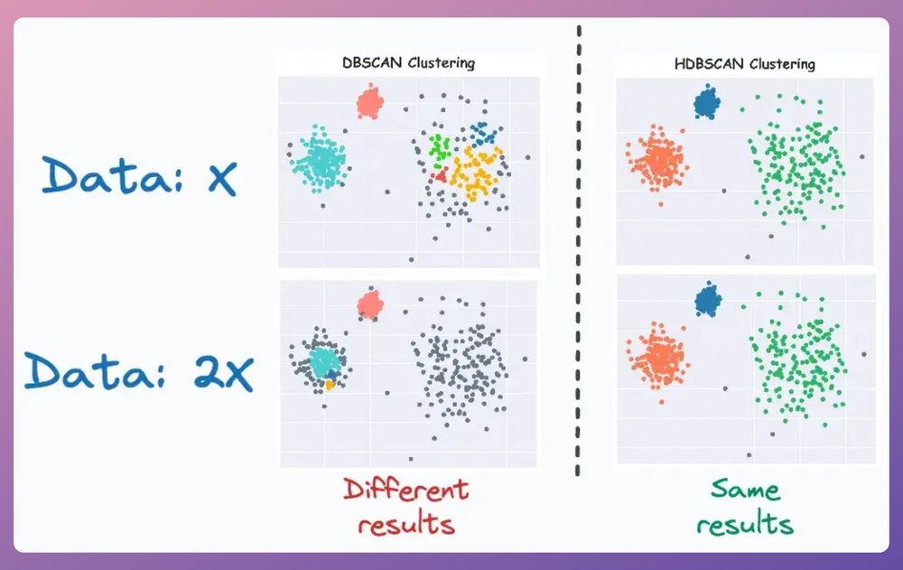

Figura 4. Comparación de resultados de DBSCAN y HDBSCAN ante cambios en la escala de los datos.

Fuente: https://blog.dailydoseofds.com/p/hdbscan-vs-dbscan

# 2 🚀 Metodología

## 2.1 Descripción del algoritmo elegido

Para hallar los clústeres óptimos, HDBSCAN emplea una series de pasos. El primer paso transforma el espacio de datos mediante una métrica llamada distancia de alcance mutua. Luego, en el segundo paso, se construye un árbol de expansión mínima (MST) que conecta todos los puntos del conjunto utilizando esta métrica, asegurando una representación eficiente de la estructura de conectividad. El tercer paso genera una jerarquía de clústeres simulando la fusión de componentes conectados a medida que se incrementa el umbral de densidad. Posteriormente, el cuarto paso condensa dicha jerarquía, eliminando subdivisiones triviales y puntos que no forman agrupaciones significativas, lo que da lugar a un árbol condensado más interpretable. Finalmente, en el quinto paso, HDBSCAN extrae los clústeres óptimos utilizando una medida de estabilidad, manteniendo clústeres estables.

### 2.1.1 📊 Transformando el espacio

El primer paso de HDBSCAN consiste en transformar el espacio original de los datos para incorporar información sobre la densidad local de cada punto. Para ello, se calcula la **core distance**, definida como la distancia mínima a la que un punto debe expandirse para alcanzar al menos un número $k$ de vecinos. Esta medida permite identificar regiones densas y distinguirlas de zonas dispersas. A partir de las core distances y de las distancias originales entre pares de puntos, se define la **distancia de alcance mutua** (*mutual reachability distance*), que se calcula como:

$$d_{\text{mreach}-k}(a, b) = \max \left\{ \text{core}_k(a),
\text{core}_k(b), d(a, b) \right\}$$

Esta métrica garantiza que los puntos en regiones de baja densidad se alejen artificialmente, mientras que los puntos en zonas densas conserven su proximidad.

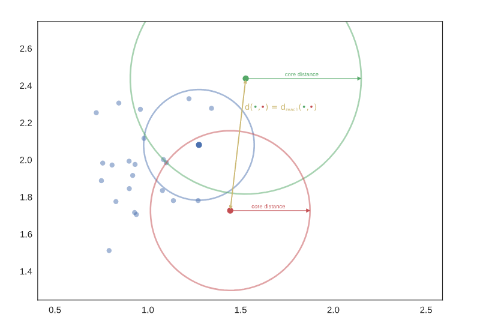

Figura 5. Cálculo de la distancia de alcance mutua entre dos puntos a partir de sus core distances.

Fuente: https://hdbscan.readthedocs.io/en/latest/how_hdbscan_works.html

### 2.1.2 📊 Construcción del arbol de expansión mínimo

En esta etapa, teniendo ya calculada la distancia de alcance mutua entre todos los pares de puntos, se procede a construir un grafo completo donde cada nodo representa un punto del conjunto de datos y cada arista está ponderada con dicha distancia. A partir de este grafo, se genera el árbol de expansión mínima (Minimum Spanning Tree, MST), que es un subgrafo acíclico que conecta todos los puntos utilizando la suma mínima posible de distancias. Este árbol se construye mediante algoritmos clásicos como el de Prim o Borůvka, y cumple una función fundamental: preservar únicamente las conexiones esenciales entre puntos, descartando aquellas redundantes que podrían introducir ruido o distorsionar la estructura de los clústeres.

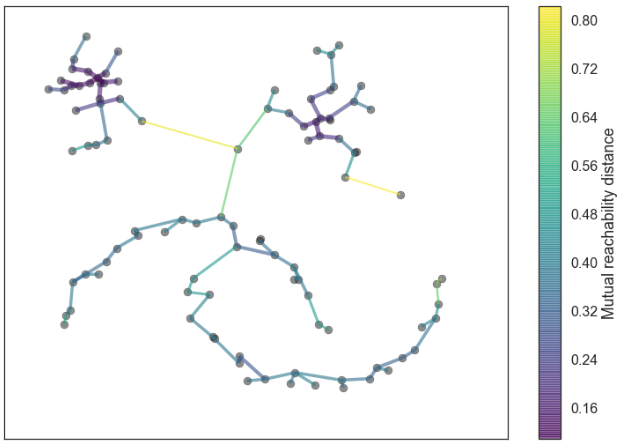

Figura 6. Árbol de expansión mínima ponderado por la distancia de alcance mutua entre puntos.

Fuente: https://hdbscan.readthedocs.io/en/latest/how_hdbscan_works.html

### 2.1.3 📊 Construir la jerarquía del clúster

Con base en el árbol de expansión mínima construido en la etapa anterior, HDBSCAN procede a generar una jerarquía de clústeres utilizando un enfoque inspirado en el método single linkage. Para ello, las aristas del árbol se ordenan en función creciente de la distancia de alcance mutua, y se van eliminando progresivamente. El resultado de este proceso es una estructura jerárquica que contiene todas las posibles agrupaciones que podrían surgir en el conjunto de datos bajo diferentes niveles de densidad. Esta jerarquía es análoga a un dendrograma, pero adaptado a datos con formas y densidades arbitrarias. Sin embargo, no todas las divisiones en la jerarquía representan clústeres significativos, por lo que es necesario aplicar un paso posterior para condensar esta estructura y extraer agrupaciones verdaderamente estables.

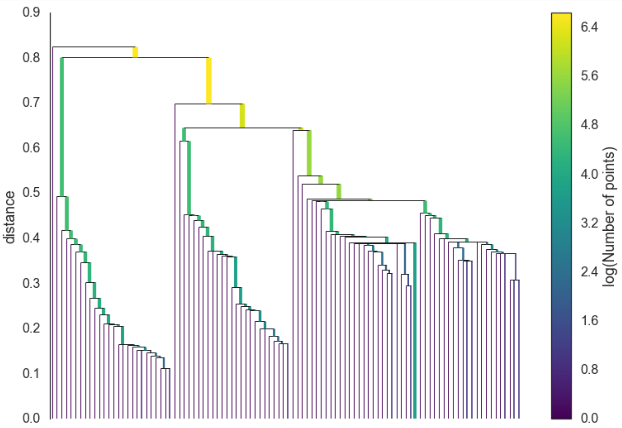

Figura 7. Jerarquía de clústeres generada mediante single linkage a partir del árbol de expansión mínima.

Fuente: https://hdbscan.readthedocs.io/en/latest/how_hdbscan_works.html

### 2.1.4 📊 Condensar el árbol de clústeres

En esta etapa se condensa la jerarquía de clústeres en una estructura más simple llamada árbol condensado. Muchas divisiones en la jerarquía no representan verdaderas particiones, sino la pérdida progresiva de puntos desde un clúster principal. Para distinguir divisiones reales, se aplica el criterio del tamaño mínimo de clúster.Una vez definido este umbral, se recorre la jerarquía de forma descendente y, en cada división, se evalúa si alguna de las ramas resultantes contiene menos puntos que min_cluster_size. Si es así, dichos puntos se consideran como puntos que abandonan el clúster principal, y la rama mayor conserva la identidad del clúster padre. En cambio, si ambas ramas resultantes superan el tamaño mínimo, se interpreta como una división legítima del clúster. Al finalizar este proceso, se obtiene un árbol condensado más pequeño, donde cada nodo contiene información sobre el número de puntos activos en distintos niveles de densidad.

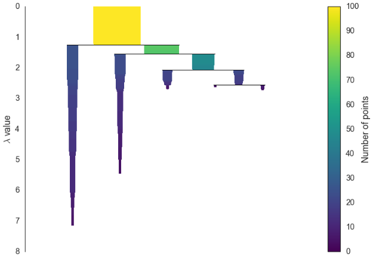

Figura 8. Árbol condensado generado por HDBSCAN para visualizar la persistencia y estabilidad de los clústeres.

Fuente: https://hdbscan.readthedocs.io/en/latest/how_hdbscan_works.html

### 2.1.5 📊 Extraer los clústeres

En esta etapa se seleccionan los **clústeres finales** a partir del árbol condensado, utilizando como criterio su **estabilidad**. Cada clúster se define en un intervalo de densidad representado por $\lambda$, donde $\lambda = \frac{1}{\text{distancia de alcance mutua}}$. Cuanto mayor sea $\lambda$, mayor es la densidad. Para cada clúster, se registra el valor $\lambda_{\text{birth}}$, correspondiente al nivel en que nace, y $\lambda_{\text{death}}$, cuando desaparece por división o por pérdida de puntos. A su vez, para cada punto $p$ que pertenece al clúster, se define $\lambda_p$ como el valor en que ese punto lo abandona.

Con esta información, la **estabilidad** de un clúster se calcula como:

$$\text{Estabilidad}(C) = \sum_{p \in C} (\lambda_p -
\lambda_{\text{birth}})$$

HDBSCAN recorre el árbol condensado en orden inverso y compara la estabilidad de cada clúster con la suma de las estabilidades de sus hijos. Si un clúster tiene mayor estabilidad que sus descendientes, se selecciona como válido y se descartan sus ramas inferiores. Del mismo modo, si los hijos de un clúster tienen mayor estabilidad en conjunto que el padre, se seleccionan los hijos y se descarta al padre. Esta regla garantiza que la partición final del conjunto de datos sea única, coherente y no solapada, manteniendo únicamente aquellas agrupaciones que hayan demostrado mayor persistencia a lo largo de los distintos niveles de densidad.Este proceso da lugar a una **partición plana del conjunto de datos**, donde solo se conservan los clústeres más persistentes. Los puntos que no pertenecen a ninguno de ellos se etiquetan como **ruido** (`label = -1`).

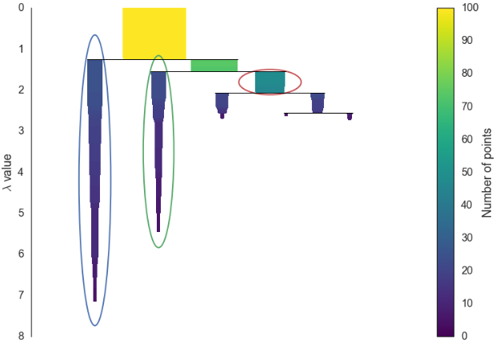

Figura 9. Clústeres extraídos en función de su estabilidad.

Fuente: https://hdbscan.readthedocs.io/en/latest/how_hdbscan_works.html

## 2.2 Ejemplo introductorio

Tenemos 7 datos, se muestra su gráfica de dispersión:

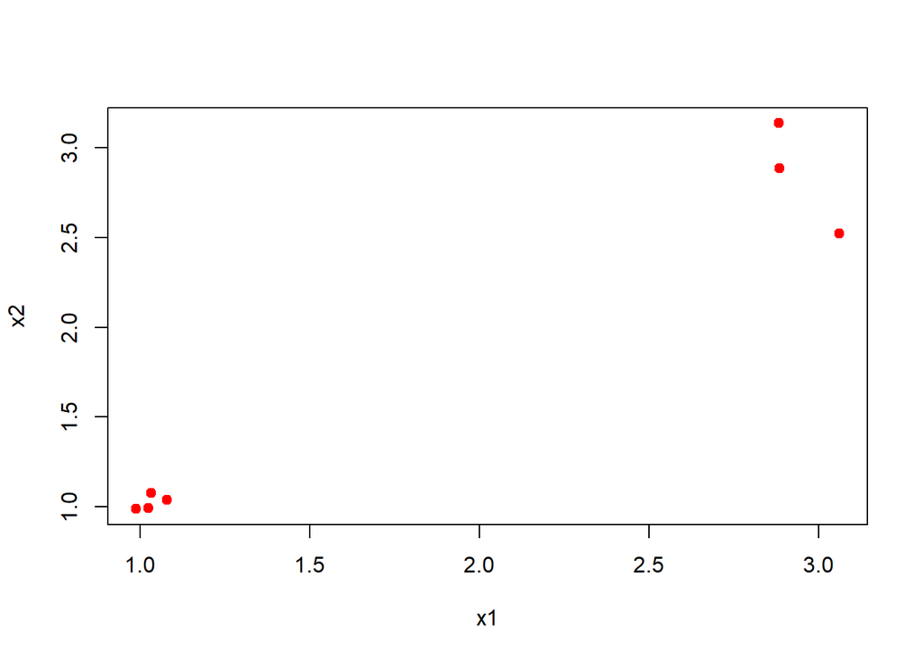

Los valores correspondientes a estos puntos se pueden ver en la siguiente tabla:

| Punto | x1 | x2 |
| --- | --- | --- |
| P0 | 1.0248 | 0.9931 |
| P1 | 1.0324 | 1.0762 |
| P2 | 0.9883 | 0.9883 |
| P3 | 1.0790 | 1.0384 |
| P4 | 2.8826 | 3.1356 |
| P5 | 2.8841 | 2.8836 |
| P6 | 3.0605 | 2.5217 |

De los cuales se calcula su core distance para cada punto, siendo un mínimo de 3 puntos que se debe alcanzar en su vecindario:

| Punto | Core Distance |
| --- | --- |
| P0 | 0.0706 |
| P1 | 0.0834 |
| P2 | 0.0983 |
| P3 | 0.0706 |
| P4 | 0.6392 |
| P5 | 0.4026 |
| P6 | 0.6392 |

Luego calculamos la distancia euclidiana entre los puntos P0 y P04:
$$\text{Distancia}(P_0, P_4) = \sqrt{(x_1^{(P_0)} - x_1^{(P_4)})^2 +
(x_2^{(P_0)} - x_2^{(P_4)})^2}
= \sqrt{(1.0248 - 2.8826)^2 + (0.9931 - 3.1356)^2} = 2.8358$$

También se muestra las distancias euclidianas entre todos los puntos:

|  | P0 | P1 | P2 | P3 | P4 | P5 | P6 |
| --- | --- | --- | --- | --- | --- | --- | --- |
| P0 | 0.0000 | 0.0834 | 0.0369 | 0.0706 | 2.8358 | 2.6516 | 2.5457 |
| P1 | 0.0834 | 0.0000 | 0.0983 | 0.0600 | 2.7686 | 2.5876 | 2.4905 |
| P2 | 0.0369 | 0.0983 | 0.0000 | 0.1036 | 2.8635 | 2.6807 | 2.5778 |
| P3 | 0.0706 | 0.0600 | 0.1036 | 0.0000 | 2.7662 | 2.5814 | 2.4752 |
| P4 | 2.8358 | 2.7686 | 2.8635 | 2.7662 | 0.0000 | 0.2521 | 0.6392 |
| P5 | 2.6516 | 2.5876 | 2.6807 | 2.5814 | 0.2521 | 0.0000 | 0.4026 |
| P6 | 2.5457 | 2.4905 | 2.5778 | 2.4752 | 0.6392 | 0.4026 | 0.0000 |

Siguiendo con el ejemplo de P0 y P4, calculamos la distancia de alcance mutua:
$$d_{\text{mreach}}(P_0, P_4) = \max \{ 0.0706,\ 0.6392,\ 2.8358 \} =
\boxed{2.8358}$$

En la tabla se muestra las distancias de alcance mutuo entre todos los puntos:

|  | P0 | P1 | P2 | P3 | P4 | P5 | P6 |
| --- | --- | --- | --- | --- | --- | --- | --- |
| P0 | 0.0000 | 0.0834 | 0.0983 | 0.0706 | 2.8358 | 2.6516 | 2.5457 |
| P1 | 0.0834 | 0.0000 | 0.0983 | 0.0834 | 2.7686 | 2.5876 | 2.4905 |
| P2 | 0.0983 | 0.0983 | 0.0000 | 0.1036 | 2.8635 | 2.6807 | 2.5778 |
| P3 | 0.0706 | 0.0834 | 0.1036 | 0.0000 | 2.7662 | 2.5814 | 2.4752 |
| P4 | 2.8358 | 2.7686 | 2.8635 | 2.7662 | 0.0000 | 0.6392 | 0.6392 |
| P5 | 2.6516 | 2.5876 | 2.6807 | 2.5814 | 0.6392 | 0.0000 | 0.6392 |
| P6 | 2.5457 | 2.4905 | 2.5778 | 2.4752 | 0.6392 | 0.6392 | 0.0000 |

El siguiente gráfico muestra la distancia de alcance mutua entre los puntos P0 y P4, que es de 2.84.

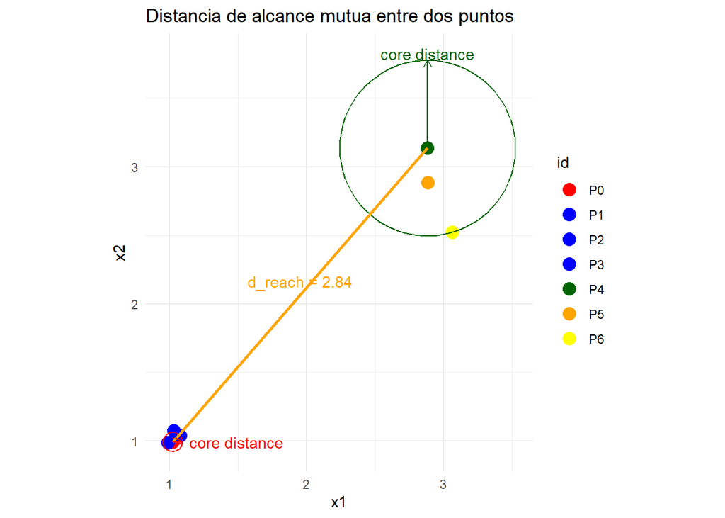

Visualizamos el árbol de expansión mínima (MST) obtenido a partir de la matriz de distancias de alcance mutua:

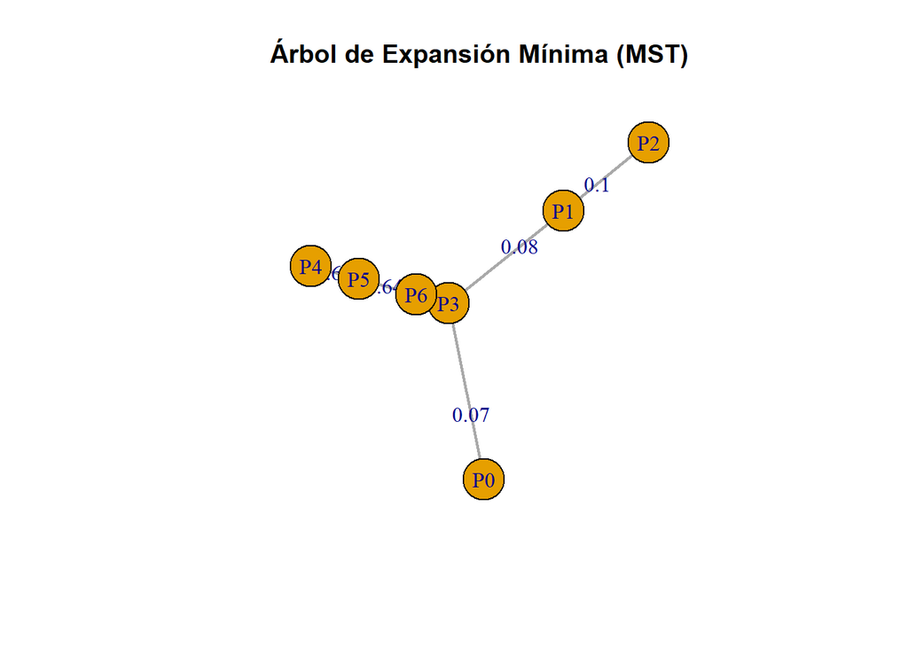

Posteriormente, se puede observar el árbol jerárquico de HDBSCAN:

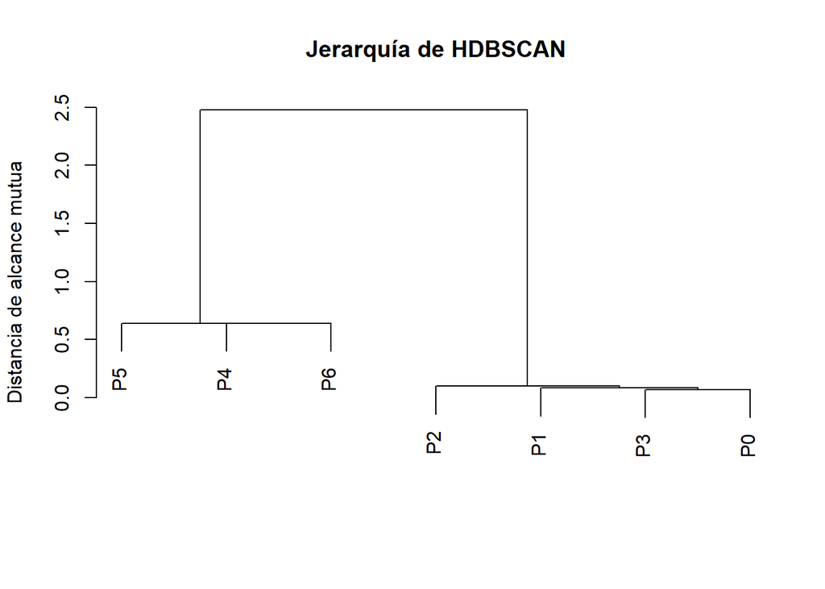

Obtenido el árbol jerárquico, se procede a obtener el árbol condensado y los cluster a extraer:

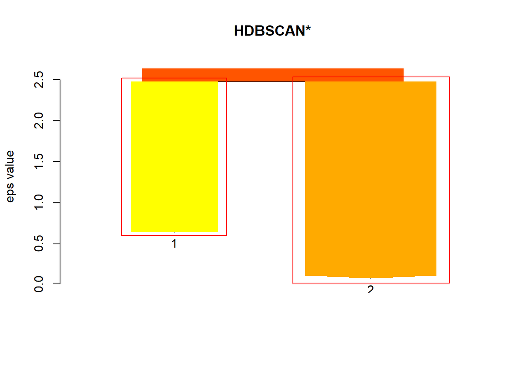

**🔎 Nota técnica:**  
Algunos programas como R muestran en el eje Y la etiqueta “eps value”, pero en realidad representan la distancia de alcance mutua.Teóricamente, debería usarse $\lambda$, que es la inversa de la distancia de alcance mutua. Sin embargo, la interpretación del eje se mantiene: en la parte superior está la menor densidad y hacia abajo, mayor densidad.

Finalmente se muestran los puntos agrupados por clústeres:

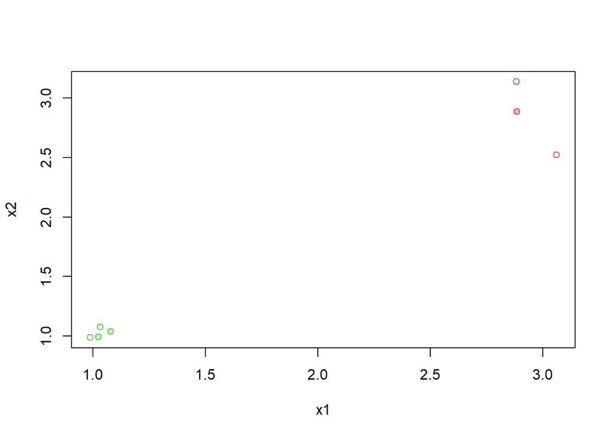

# 3 🚀 Presentación del caso

La presenta aplicación se centra en la detección de patrones en el estado nutricional de gestantes atendidas durante el año 2024 en establecimientos de Salud de Lima Norte pertenecientes al Ministerio de Salud. Esta información recolectada por el Sistema de Información del Estado Nutricional (SIEN), tiene como finalidad generar información oportuna para la toma de decisiones y planificación de intervenciones a diferentes escalas que contribuyan a la mejora de calidad de vida en el Perú. El SIEN desde el 2003, realiza los procesos de registro hasta el análisis del estado nutricional de niños, adolescentes y gestantes que acuden a los establecimientos de salud del Ministerio de Salud (MINSA) en el Perú.

Los datos originales recolectados son de 24657 registros de gestantes en Lima Norte, pero para fines acádemicos se ha seleccionado una muestra de 5089 registros.

El objetivo principal es identificar grupos o perfiles de gestantes con características nutricionales similares, lo cual podría servir como insumo para estrategias focalizadas de prevención de anemia, bajo peso materno y otras condiciones asociadas al embarazo.

# 4 🚀 Descripción de los datos

## 4.1 Variables

📊 Variables predictivas seleccionadas para clustering:

| Variable | Tipo | Observación |
| --- | --- | --- |
| `Peso` | Numérica | Peso de la gestante al momento del control |
| `Talla` | Numérica | Talla en cm |
| `Peso pregestacional (Ppg)` | Numérica | Peso antes del embarazo |
| `Hemoglobina` | Numérica | g/dL, usada para evaluar anemia |
| `Edad_Gest` | Numérica | Edad gestacional en semanas |
| `Edad` | Numérica | Edad de la gestante al momento del control |

**Nota:** En el dataset original se registró mayor información como fechas de control, entre otros, sin embargo no se consideran apropiados para el análisis de clustering.

## 4.2 Número de datos

Nuestra muestra contiene un total de 5089 registros de gestantes atendidas en Lima Norte durante el año 2024.

## 4.3 Periodicidad

Nuestra muestra registra fechas de atención desde el 1 de enero hasta el 30 de Setiembre de 2024.

# 5 🚀 Resultados

## 5.1 Resultados con el algoritmo elegido: HDBSCAN

### 5.1.1 Análisis exploratorio de los datos

Configuración del entorno de trabajo:

```r
rm(list = ls())
graphics.off()
options(scipen = 999)    # Eliminar la notación científica
options(digits = 3)      # El número de decimales
setwd(dirname(rstudioapi::getActiveDocumentContext()$path))
getwd()
```

```
## [1] "D:/MAESTRIA UNALM/CII_TEC_REC_PATRONES/Trabajo_Final"
```

Carga de librerías:

```r
library(pacman)
p_load(readxl, dplyr, ggplot2, tidyr,forcats, ggplot2, scales,
       dbscan, fpc, factoextra, cluster, DBCVindex, tidyr, Rtsne)
```

Lectura de datos

```r
df <- read_excel("dataset_muestra.xlsx")
```

Selección de variables de predictivas

```r
variables_predictoras <- c("Peso", "Talla", "Ppg", "Edad_Gest",
                           "Hemoglobina", "Edad")
```

Estadística descriptiva

```r
# Seleccionar las variables predictivas y calcular estadísticas descriptivas
resumen_stats <- df %>%
  select(all_of(variables_predictoras)) %>%
  summary()
print(resumen_stats)
```

```
##       Peso          Talla          Ppg         Edad_Gest     Hemoglobina
##  Min.   :53.0   Min.   :144   Min.   :44.0   Min.   : 8.0   Min.   : 9.2
##  1st Qu.:64.0   1st Qu.:150   1st Qu.:54.0   1st Qu.:36.0   1st Qu.:11.3
##  Median :69.0   Median :153   Median :59.0   Median :37.0   Median :11.9
##  Mean   :69.2   Mean   :154   Mean   :59.3   Mean   :36.3   Mean   :11.9
##  3rd Qu.:74.1   3rd Qu.:156   3rd Qu.:64.0   3rd Qu.:38.0   3rd Qu.:12.5
##  Max.   :90.2   Max.   :164   Max.   :82.0   Max.   :40.0   Max.   :14.5
##       Edad
##  Min.   :13.0
##  1st Qu.:23.0
##  Median :28.0
##  Mean   :28.3
##  3rd Qu.:33.0
##  Max.   :50.0
```

```r
summarytools::descr(df[,variables_predictoras])
```

```
## Descriptive Statistics
## df
## N: 5089
##
##                        Edad   Edad_Gest   Hemoglobina      Peso       Ppg     Talla
## ----------------- --------- ----------- ------------- --------- --------- ---------
##              Mean     28.28       36.28         11.86     69.18     59.34    153.45
##           Std.Dev      6.47        4.13          0.82      7.06      7.01      3.60
##               Min     13.00        8.00          9.20     53.00     44.00    144.00
##                Q1     23.00       36.00         11.30     64.00     54.00    150.50
##            Median     28.00       37.00         11.90     69.00     59.00    153.20
##                Q3     33.00       38.00         12.50     74.10     64.00    156.00
##               Max     50.00       40.00         14.50     90.20     82.00    164.00
##               MAD      7.41        1.48          0.89      7.41      7.41      4.15
##               IQR     10.00        2.00          1.20     10.10     10.00      5.50
##                CV      0.23        0.11          0.07      0.10      0.12      0.02
##          Skewness      0.15       -3.95         -0.10      0.18      0.26      0.08
##       SE.Skewness      0.03        0.03          0.03      0.03      0.03      0.03
##          Kurtosis     -0.72       19.49         -0.14     -0.59     -0.51     -0.52
##           N.Valid   5089.00     5089.00       5089.00   5089.00   5089.00   5089.00
##                 N   5089.00     5089.00       5089.00   5089.00   5089.00   5089.00
##         Pct.Valid    100.00      100.00        100.00    100.00    100.00    100.00
```

Gráficos para variables predictoras

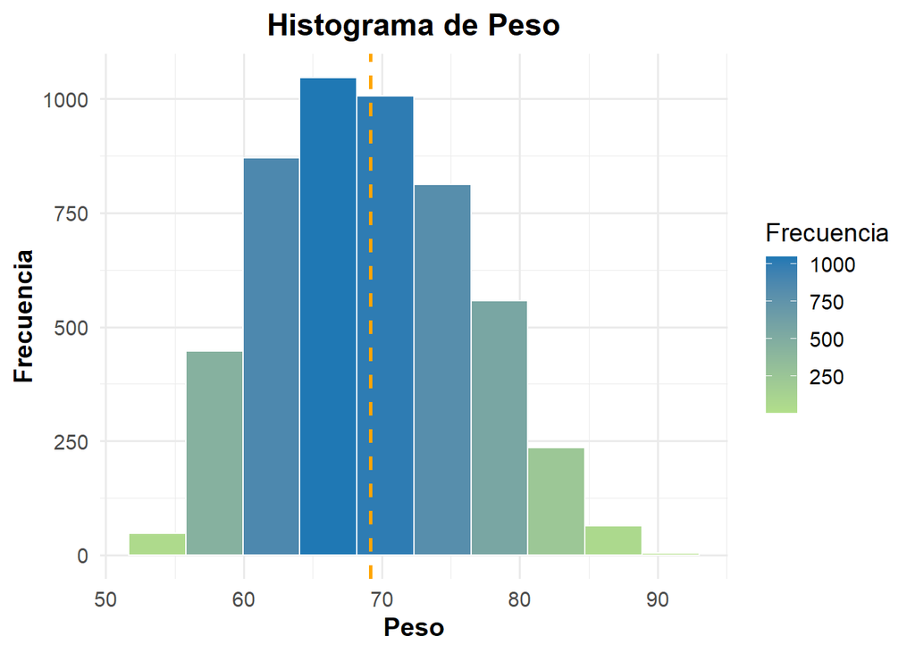

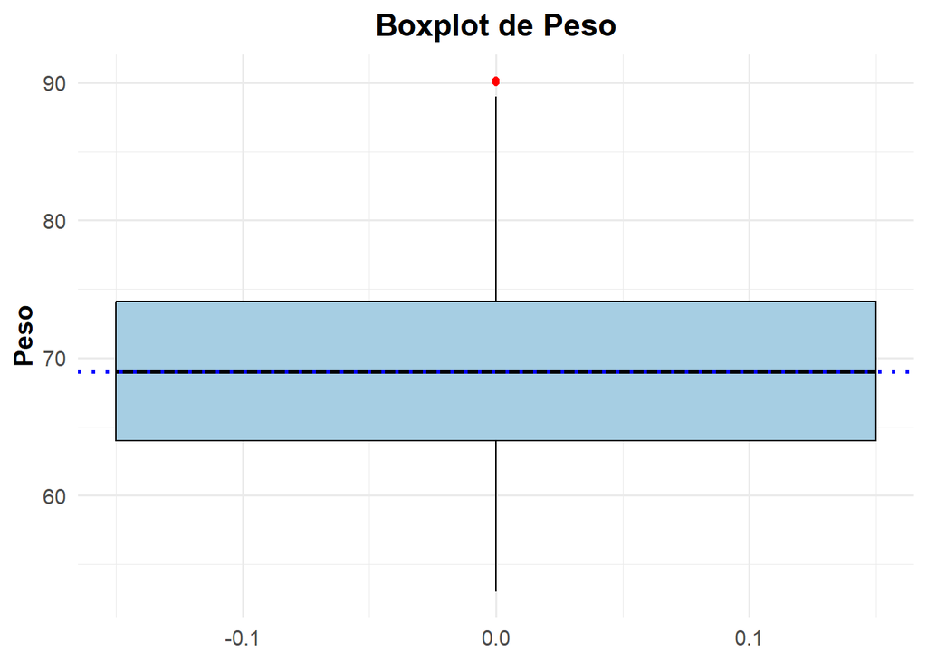

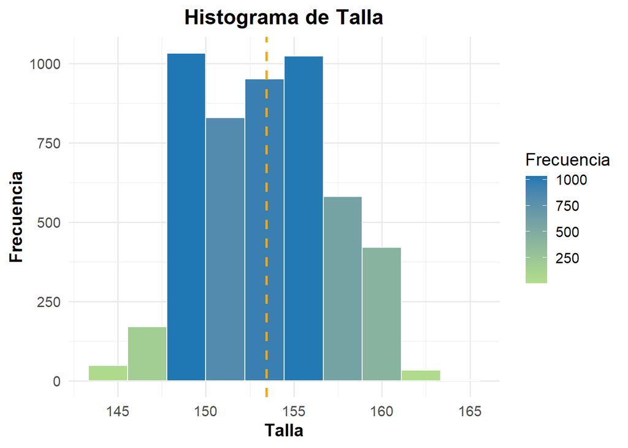

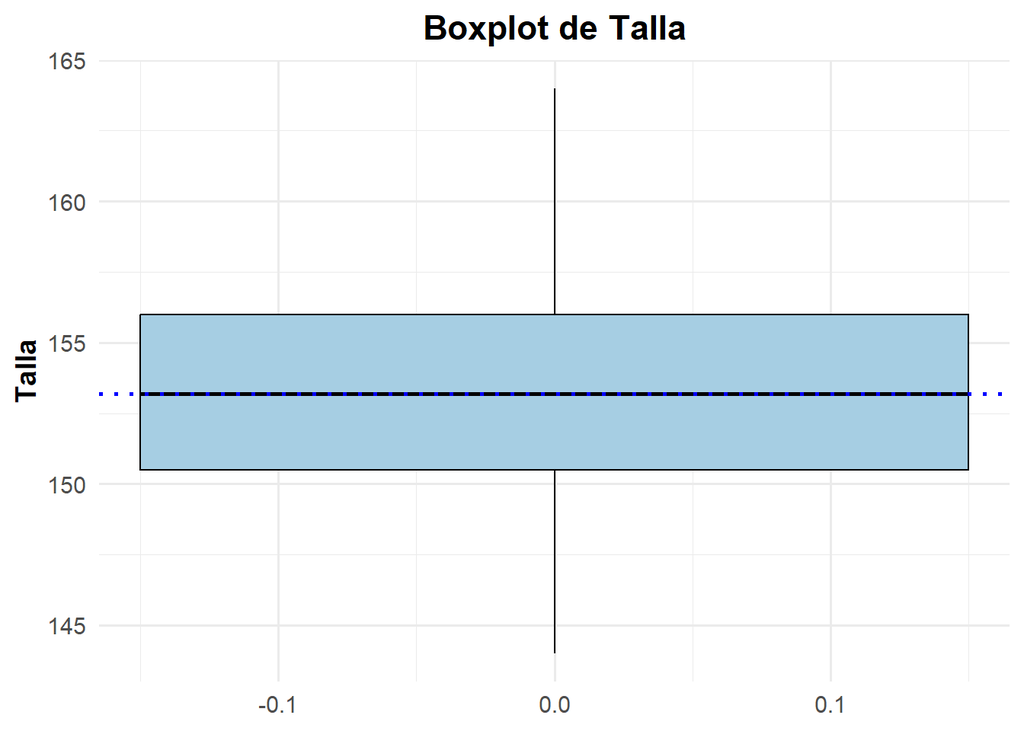

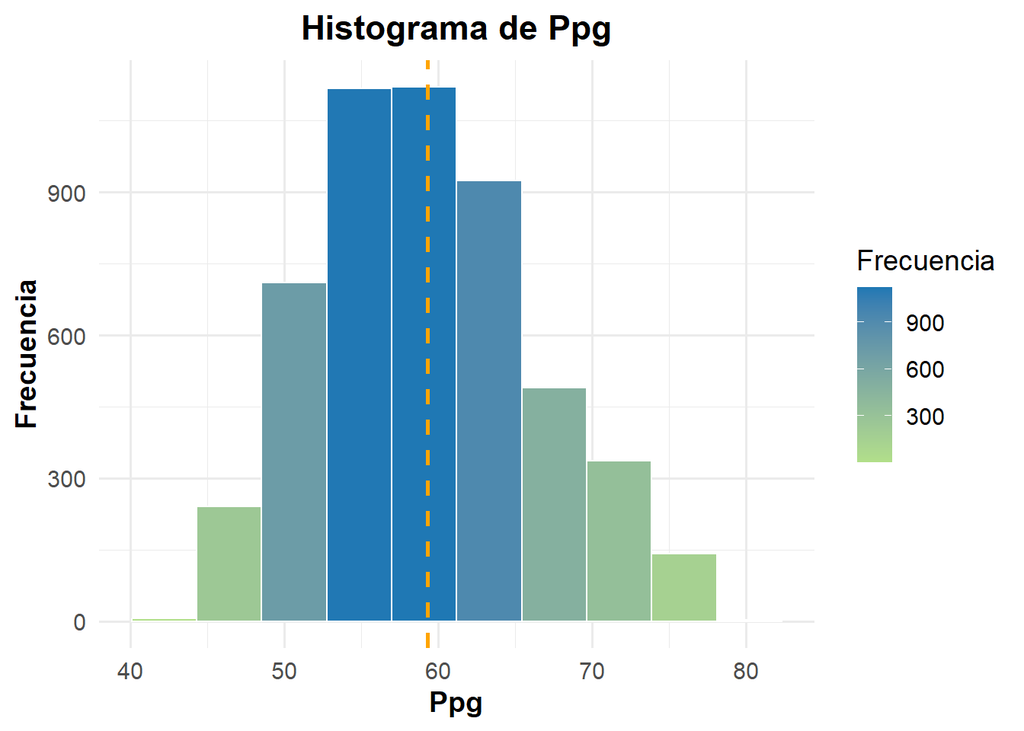

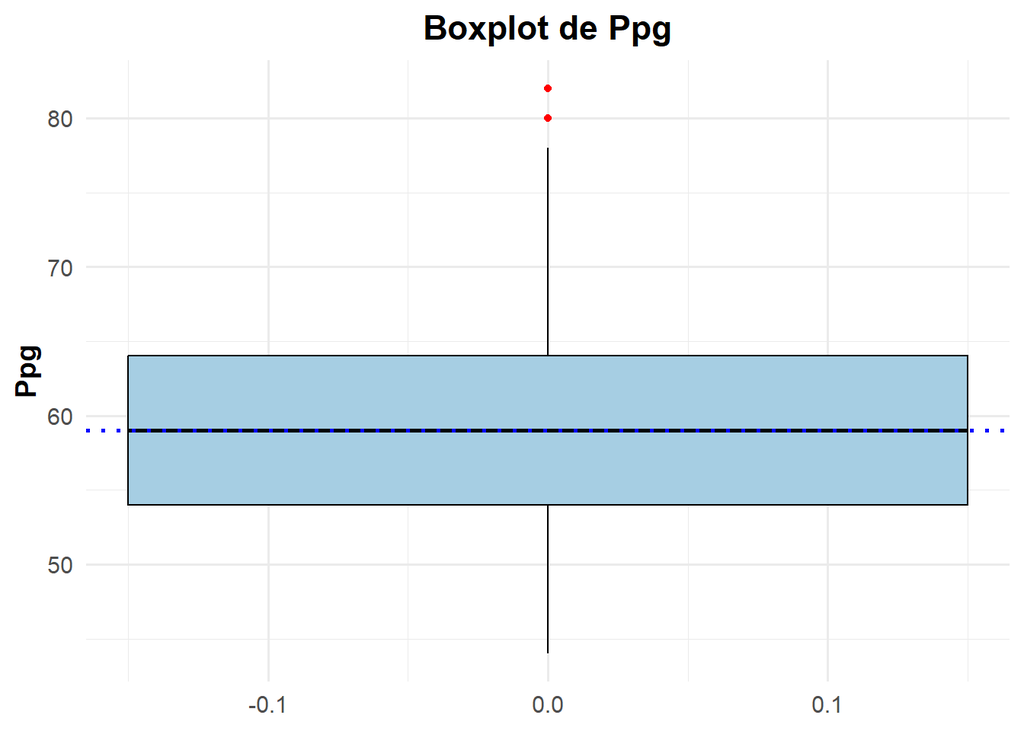

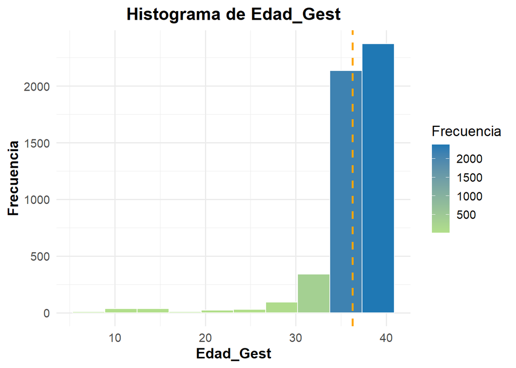

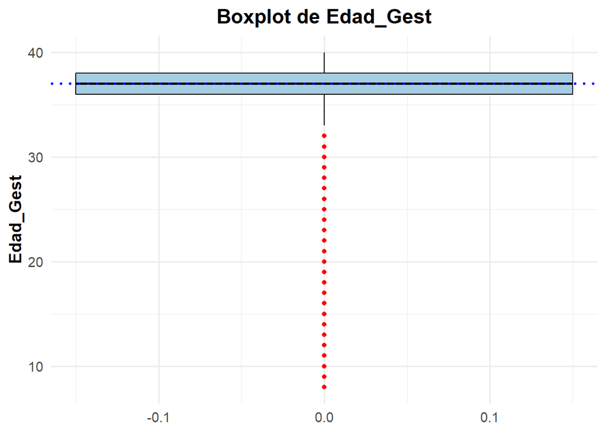

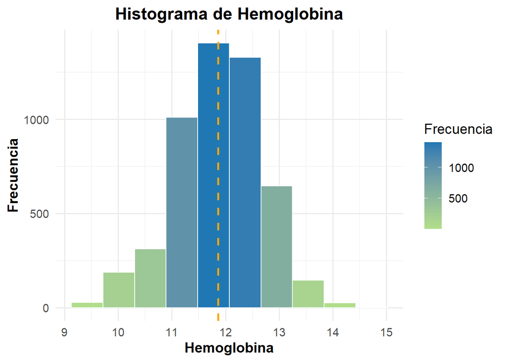

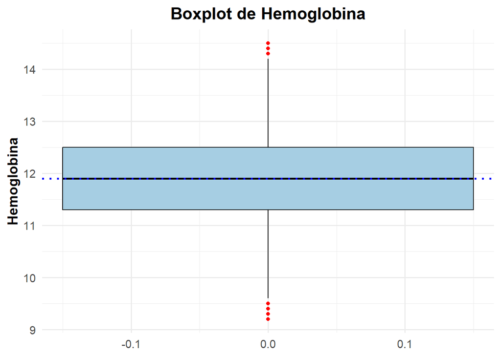

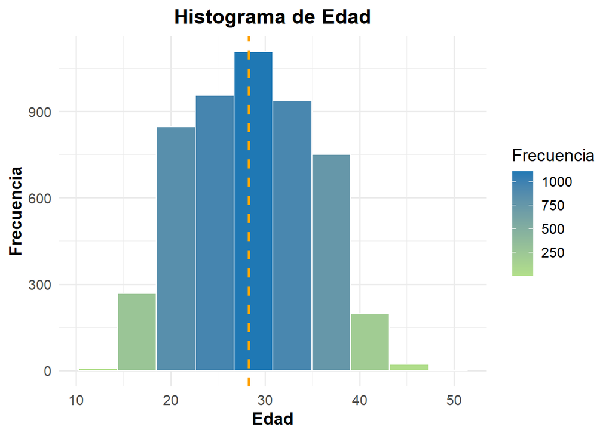

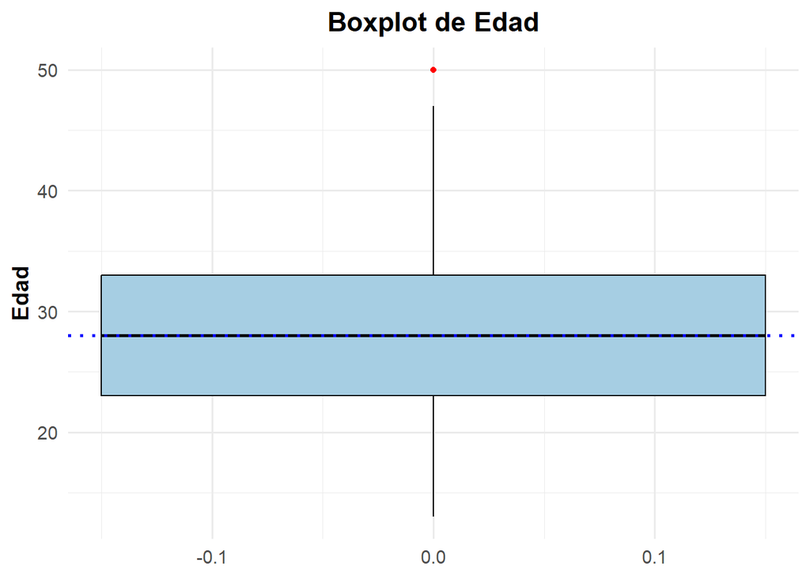

```r
# Bucle para crear histogramas y boxplots de las variables predictoras
for (var in variables_predictoras) {
  # Histograma con línea de media y mejor estética
  p_hist <- ggplot(df, aes_string(x = var)) +
    geom_histogram(aes(fill = ..count..), bins = 10, color = "white") +
    scale_fill_gradient(low = "#b2df8a", high = "#1f78b4") +
    geom_vline(
      aes(xintercept = mean(df[[var]], na.rm = TRUE)),
      color = "orange", linetype = "dashed", size = 1
    ) +
    labs(
      title = paste("Histograma de", var),
      x = var,
      y = "Frecuencia",
      fill = "Frecuencia"
    ) +
    theme_minimal(base_size = 14) +
    theme(
      plot.title = element_text(hjust = 0.5, face = "bold"),
      axis.title = element_text(face = "bold"),
      legend.position = "right"
    )

  print(p_hist)

  # Boxplot con línea de mediana
  p_box <- ggplot(df, aes_string(y = var)) +
    geom_boxplot(fill = "#a6cee3", color = "black", outlier.color = "red", outlier.shape = 16, width = 0.3) +
    geom_hline(
      yintercept = median(df[[var]], na.rm = TRUE),
      linetype = "dotted",
      color = "blue",
      size = 1
    ) +
    labs(
      title = paste("Boxplot de", var),
      y = var
    ) +
    theme_minimal(base_size = 14) +
    theme(
      plot.title = element_text(hjust = 0.5, face = "bold"),
      axis.title = element_text(face = "bold")
    )

  print(p_box)
}
```

### 5.1.2 Pre - procesamiento

```r
# Filtrar las columnas de interés y convertir a numérico, eliminar duplicados
df_filtrado <- df %>%
  select(all_of(variables_predictoras)) %>%
  mutate(across(everything(), as.numeric)) %>%
  distinct()

# Conversión a matriz y escalado de los datos
X_raw <- as.matrix(df_filtrado)
X <- scale(X_raw)
```

### 5.1.3 Ajuste del modelo

```r
# Valores de minPts a probar
minPts_vals <- c(10, 20, 30, 40)

# Inicializar resultados
resultados <- data.frame(minPts = integer(), DBCV = numeric(),
                         clusters = integer(), outliers = integer())

# Lista para guardar cada modelo
modelos_hdbscan <- list()

# Bucle principal
for (m in minPts_vals) {

  modelo <- hdbscan(X, minPts = m)
  etiquetas <- modelo$cluster
  # Guardar el modelo en la lista
  modelos_hdbscan[[paste0("minPts_", m)]] <- modelo

  # Calcular Índice de validación de agrupamiento basado en la densidad (DBCV)
  dbcv <- dbcv_index(data = X, partition = etiquetas, noiseLabel = 0)

  # Contar clústeres y outliers
  n_clusters <- length(unique(etiquetas[etiquetas != 0]))
  n_outliers <- sum(etiquetas == 0)

  resultados <- rbind(resultados, data.frame(
    minPts = m,
    DBCV = round(dbcv, 4),
    clusters = n_clusters,
    outliers = n_outliers
  ))
}

# Mostrar resumen
print(resultados)
```

```
##   minPts  DBCV clusters outliers
## 1     10 0.658        2      242
## 2     20 0.714        2      222
## 3     30 0.687        2      187
## 4     40 0.000        0     5089
```

Interpretación: Se puede observar que el valor de `minPts = 20` tiene el mejor índice DBCV, con un total de 2 clústeres y outliers. Por lo tanto, se selecciona este modelo para continuar con el análisis.

**🔎 Índice de Validación de Agrupamiento Basado en Densidad:**  
DBCV (Density-Based Clustering Validation) mide qué tan bien definidos están los clústeres en términos de densidad. DBCV no asume formas esféricas ni tamaños similares, lo que lo hace especialmente adecuado para evaluar resultados de clustering basado en densidad, donde los grupos pueden tener formas irregulares o densidades distintas.

- Rango: -1 a 1
- Interpretación:

Cercano a 1, implica clústeres bien separados y compactos (alta calidad); cercano a 0 implica separación o densidad poco clara; Negativo implica clústeres mal definidos (mezcla de densidades o solapamiento fuerte).

**Conteo de registros por clúster**

```r
table(modelos_hdbscan$minPts_20$cluster)
```

```
##
##    0    1    2
##  222 4825   42
```

Se observa que los outliers detectados son 222, el cluster 1 es el grupo predominante con 4825 registros, y el cluster 2 tiene 42 registros, siendo el grupo con menor cantidad de registros.

### 5.1.4 Caracterización de los clústeres obtenidos con HDBSCAN

**Gráfico de clústeres utilizando t-SNE** *El t-SNE (t-distributed Stochastic Neighbor Embedding) es una técnica de reducción de dimensionalidad no lineal, usada principalmente para visualizar datos de alta dimensión en 2D o 3D, preservando la estructura local de los datos*.

```r
# Generar reducción de dimensionalidad con t-SNE
set.seed(42)
tsne_res <- Rtsne(as.matrix(X),
                  dims = 2, verbose = TRUE, max_iter = 500)
```

```
## Performing PCA
## Read the 5089 x 6 data matrix successfully!
## OpenMP is working. 1 threads.
## Using no_dims = 2, perplexity = 30.000000, and theta = 0.500000
## Computing input similarities...
## Building tree...
## Done in 0.91 seconds (sparsity = 0.022550)!
## Learning embedding...
## Iteration 50: error is 90.378464 (50 iterations in 1.44 seconds)
## Iteration 100: error is 84.783125 (50 iterations in 1.20 seconds)
## Iteration 150: error is 84.564783 (50 iterations in 0.84 seconds)
## Iteration 200: error is 84.478351 (50 iterations in 0.93 seconds)
## Iteration 250: error is 84.376314 (50 iterations in 0.92 seconds)
## Iteration 300: error is 2.853548 (50 iterations in 0.78 seconds)
## Iteration 350: error is 2.512559 (50 iterations in 0.56 seconds)
## Iteration 400: error is 2.328606 (50 iterations in 0.75 seconds)
## Iteration 450: error is 2.215418 (50 iterations in 1.03 seconds)
## Iteration 500: error is 2.138608 (50 iterations in 0.69 seconds)
## Fitting performed in 9.14 seconds.
```

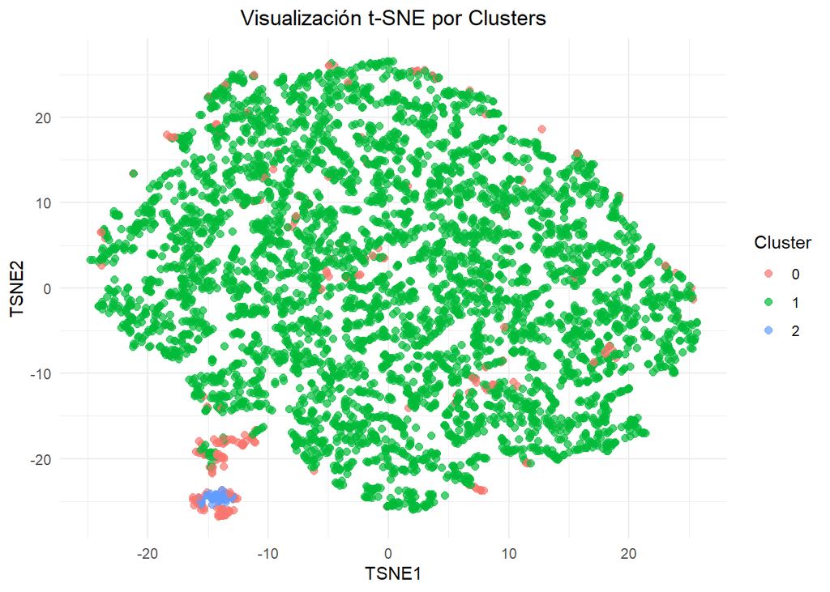

```r
# Convertir resultados de t-SNE a un DataFrame
df_tsne_plot <- df_filtrado %>%
  mutate(TSNE1 = tsne_res$Y[,1],
         TSNE2 = tsne_res$Y[,2])

# Asignar clústeres del mejor modelo al DataFrame de t-SNE
df_tsne_plot$cluster <- modelos_hdbscan$minPts_20$cluster

# Graficar los resultados de t-SNE por clústeres
ggplot(df_tsne_plot, aes(x = TSNE1, y = TSNE2, color = as.factor(cluster))) +
  geom_point(size = 2, alpha = 0.7) +
  theme_minimal() +
  labs(title = "Visualización t-SNE por Clusters",
       color = "Cluster") +
  theme(plot.title = element_text(hjust = 0.5))
```

**Promedio de variables por clúster**

```r
# Asignar clústeres al DataFrame filtrado
df_filtrado$cluster <- modelos_hdbscan$minPts_20$cluster
# Filtrar los datos excluyendo el clúster 0 (outliers)
df_filtrado_sin_out <- df_filtrado %>%
  filter(cluster != 0)

# Calcular la media por clúster para las variables numéricas
tabla_promedios <- df_filtrado_sin_out %>%
  group_by(cluster) %>%
  summarise(across(where(is.numeric) & !any_of("cluster"), mean, na.rm = TRUE))

# Mostrar la tabla
print(tabla_promedios)
```

```
## # A tibble: 2 × 7
##   cluster  Peso Talla   Ppg Edad_Gest Hemoglobina  Edad
##     <dbl> <dbl> <dbl> <dbl>     <dbl>       <dbl> <dbl>
## 1       1  69.4  153.  59.3      36.9        11.9  28.2
## 2       2  62.7  154.  62.5      13.3        12.4  31.1
```

Interpretación:

Se observa que la edad gestacional o semana de gestación, el peso actual y el peso pregestacional son variables que presentan diferencias significativas entre los clústeres.

**Gráfico de líneas por clúster**

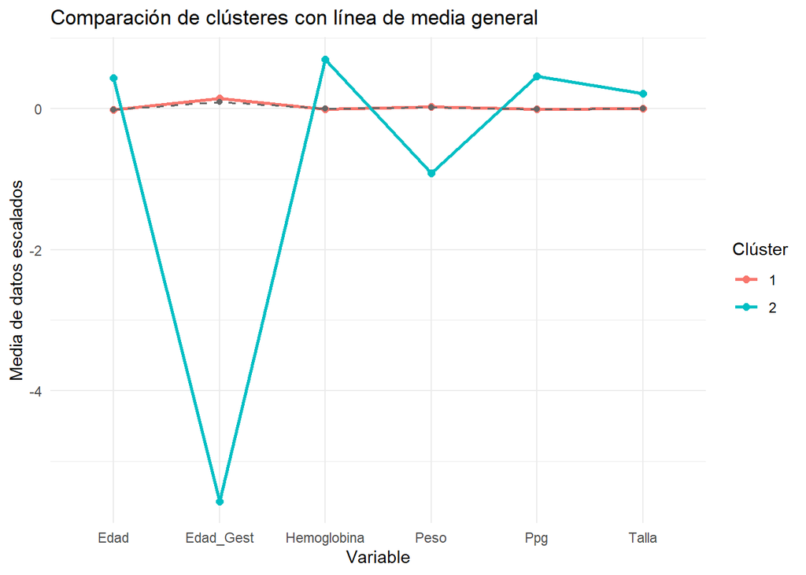

```r
# Asignar clústeres del mejor modelo al DataFrame escalado
df_scal <- as.data.frame(X)
df_scal$cluster <- modelos_hdbscan$minPts_20$cluster

# Filtrar los datos excluyendo el clúster 0
df_scal_sin_out <- df_scal %>% filter(cluster != 0)

# Calcular media general (Clústeres 1 y 2)
media_general <- df_scal_sin_out %>%
  select(-cluster) %>%
  summarise(across(everything(), mean)) %>%
  pivot_longer(cols = everything(),
               names_to = "Variable", values_to = "Valor") %>%
  mutate(Clúster = "Media general")

# Tabla promedios en formato largo
media_clusters <- df_scal_sin_out %>%
  group_by(cluster) %>%
  summarise(across(where(is.numeric), mean), .groups = "drop") %>%
  pivot_longer(cols = -cluster, names_to = "Variable", values_to = "Valor") %>%
  mutate(Clúster = as.character(cluster))

# Unir todos los datos
df_plot <- bind_rows(media_clusters, media_general)

# Graficar
ggplot(df_plot, aes(x = Variable, y = Valor, group = Clúster, color = Clúster)) +

  # Clústeres normales
  geom_line(data = df_plot %>% filter(Clúster != "Media general"), size = 1) +
  geom_point(data = df_plot %>% filter(Clúster != "Media general"), size = 2) +

  # Línea de media general
  geom_line(data = df_plot %>% filter(Clúster == "Media general"),
            aes(group = Clúster), color = "gray40", linetype = "dashed", size = 0.6) +
  geom_point(data = df_plot %>% filter(Clúster == "Media general"),
             aes(group = Clúster), color = "gray40", size = 1.5) +

  labs(
    title = "Comparación de clústeres con línea de media general",
    y = "Media de datos escalados",
    color = "Clúster"
  ) +
  theme_minimal()
```

Interpretación de los resultados:

Cluster 1 - “Gestantes en etapa final con mayor peso y menor hemoglobobina”: El primer grupo de gestantes se caracteriza por encontrarse en una etapa avanzada del embarazo, con una edad gestacional promedio de 36.9 semanas, lo que implica una mayor demanda nutricional y metabólica. Presentan un peso actual elevado (69.4 kg) en relación con su talla promedio de 153 cm, lo que sugiere un posible sobrepeso o índice de masa corporal alto, condición que podría aumentar el riesgo de complicaciones obstétricas. Además, sus niveles de hemoglobina (11.9 g/dL) bordean el umbral de anemia durante el embarazo(<11 g/dL, según la OMS) , lo cual requiere vigilancia, ya que una deficiencia de hierro en esta etapa puede afectar tanto a la madre como al feto. Por todo ello, este grupo debería ser monitoreado más de cerca en los controles prenatales.

Cluster 2- “Gestantes al inicio del embarazo, peso estable y buena hemoglobina”: El segundo grupo de gestantes se encuentra en una etapa temprana del embarazo, con una edad gestacional promedio de 13.3 semanas, correspondiente al primer trimestre. Presentan niveles adecuados de hemoglobina (12.4 g/dL), dentro del rango normal, lo que indica un buen estado hematológico inicial. Además, el peso actual es muy similar al peso pregestacional, lo cual es esperable en esta fase del embarazo, donde aún no se produce un aumento significativo de peso. Con una edad promedio de 31.1 años, estas gestantes muestran un perfil clínico estable.

## 5.2 Comparación con el algoritmo desarrollado en clase: DBSCAN

**Nota**: Se presenta el tuneo de parámetros(eps) para el mejor tamaño mínimo de puntos en DBSCAN (30), dado que previamente se hizo una exploración de combinaciones de diferentes tamaños de puntos con diferentes eps, pero por motivos de practicidad se presenta la mejor opción.

### 5.2.1 Ajuste del modelo

**Gráfico de distancias kNN para determinar el valor óptimo de eps**

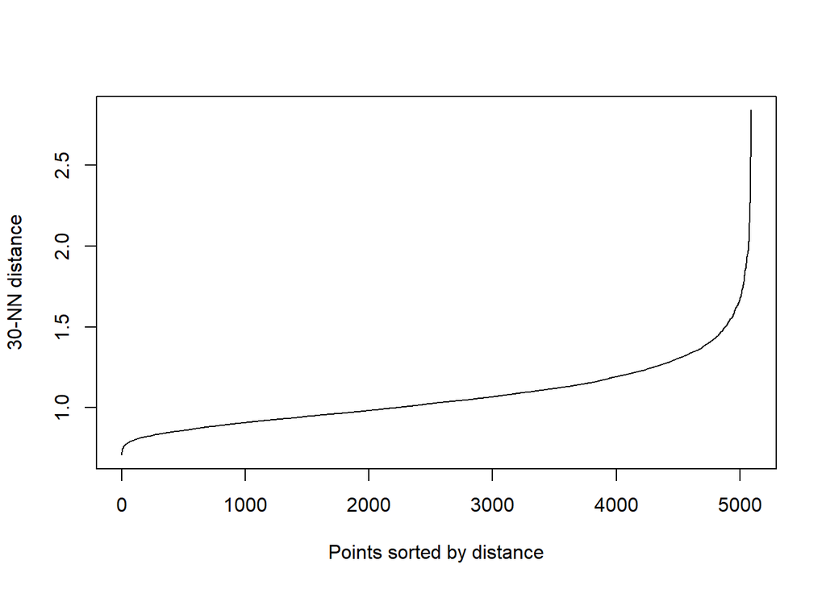

```r
kNNdistplot(X, k = 30)
```

Tuneo de hiperparámetros para DBSCAN:

```r
# Valores de eps a probar para DBSCAN
eps_vals <- c(1.2, 1.3, 1.4, 1.5)
minPts_dbscan <- 30

# Inicializar resultados para DBSCAN
resultados_dbscan <- data.frame(eps = numeric(),
                                DBCV = numeric(),
                                clusters = integer(),
                                outliers = integer())

# Lista para guardar cada modelo
modelos_dbscan <- list()

for (e in eps_vals) {

  modelo <- dbscan::dbscan(X, eps = e, minPts = minPts_dbscan)
  etiquetas <- modelo$cluster

  modelos_dbscan[[paste0("eps_", e)]] <- modelo

  dbcv <- dbcv_index(data = X, partition = etiquetas, noiseLabel = 0)

  n_clusters <- length(unique(etiquetas[etiquetas != 0]))
  n_outliers <- sum(etiquetas == 0)

  resultados_dbscan <- rbind(resultados_dbscan, data.frame(
    eps = e,
    DBCV = round(dbcv, 4),
    clusters = n_clusters,
    outliers = n_outliers
  ))
}

print(resultados_dbscan)
```

```
##   eps   DBCV clusters outliers
## 1 1.2  0.000        1      171
## 2 1.3  0.378        2       79
## 3 1.4 -0.151        2       33
## 4 1.5 -0.339        2       17
```

Interpretación: Se puede observar que el valor de `eps = 1.3` tiene el mejor índice de validación de clustering (DBCV), con un total de 2 clústeres y outliers. Por lo tanto, se selecciona este modelo para continuar con el análisis. Sin embargo, el valor de la métrica de validación es menor comparado al mejor modelo de HDBSCAN, lo que indica que la calidad de los clústeres obtenidos con DBSCAN es inferior.

**Conteo de registros por clúster**

```r
table(modelos_dbscan$eps_1.3$cluster)
```

```
##
##    0    1    2
##   79   61 4949
```

Se observa que los outliers detectados por DBSCAN son 79, el cluster 2 es el grupo predominante con 4949 registros, y el cluster 1 tiene 61 registros, siendo el grupo con menor cantidad de registros.

### 5.2.2 Caracterización de los clústeres obtenidos con DBSCAN

**Gráfico de clústeres utilizando t-SNE**

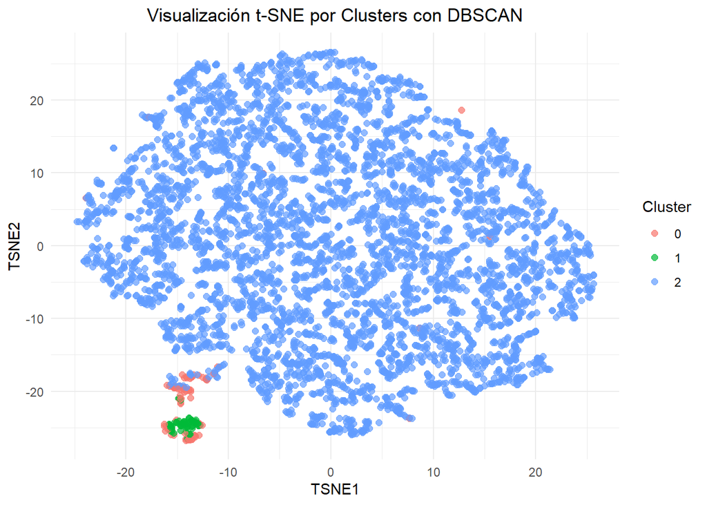

```r
# Agregar columna de cluster obtenido con DBSCAN al DataFrame de t-SNE
df_tsne_plot$cluster_dbcscan <- modelos_dbscan$eps_1.3$cluster

ggplot(df_tsne_plot, aes(x = TSNE1, y = TSNE2, color = as.factor(cluster_dbcscan))) +
  geom_point(size = 2, alpha = 0.7) +
  theme_minimal() +
  labs(title = "Visualización t-SNE por Clusters con DBSCAN",
       color = "Cluster") +
  theme(plot.title = element_text(hjust = 0.5))
```

**Promedio de variables por clúster según DBSCAN**

```r
# Asignar clústeres del modelo DBSCAN al DataFrame filtrado
df_filtrado$cluster_dbscan <- modelos_dbscan$eps_1.3$cluster
# Filtrar los datos excluyendo el clúster 0 (outliers)
df_filtrado_sin_out_db <- df_filtrado %>%
  filter(cluster_dbscan != 0)

# Calcular la media por clúster para las variables numéricas
tabla_promedios_db <- df_filtrado_sin_out_db %>%
  group_by(cluster_dbscan) %>%
  summarise(across(where(is.numeric) & !any_of("cluster"), mean, na.rm = TRUE))

# Mostrar la tabla
print(tabla_promedios_db)
```

```
## # A tibble: 2 × 7
##   cluster_dbscan  Peso Talla   Ppg Edad_Gest Hemoglobina  Edad
##            <int> <dbl> <dbl> <dbl>     <dbl>       <dbl> <dbl>
## 1              1  62.5  154.  62.2      13.2        12.4  30.9
## 2              2  69.4  153.  59.3      36.8        11.8  28.2
```

Interpretación: los promedios de las variables para los dos grupos son muy similares a los obtenidos con HDBSCAN, lo que indica que DBSCAN también ha logrado identificar los dos grupos de gestantes con características nutricionales diferentes.

**Gráfico de líneas por clúster según DBSCAN**

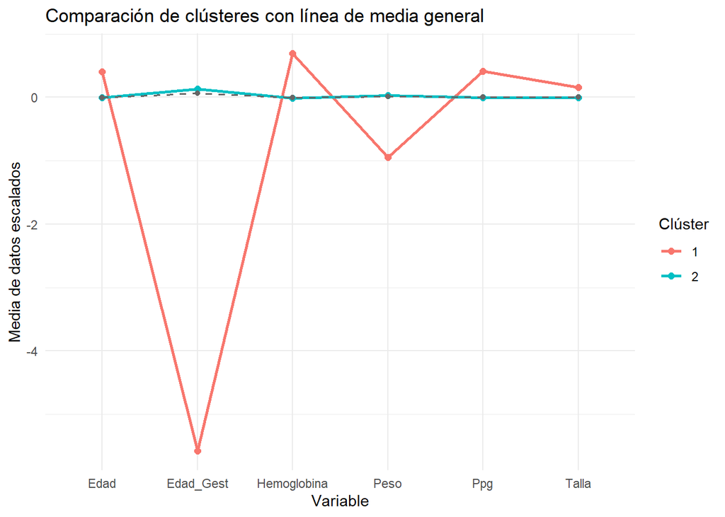

```r
# Asignar clústeres del modelo DBSCAN al DataFrame escalado
df_scal$cluster_db <- modelos_dbscan$eps_1.3$cluster

# Filtrar los datos excluyendo el clúster 0 (es decir, los outliers)
df_scal_sin_out_db <- df_scal %>% filter(cluster_db != 0)

# Calcular media general (Clústeres 1 y 2)
media_general_db <- df_scal_sin_out_db %>%
  select(-cluster_db, -cluster) %>%
  summarise(across(everything(), mean)) %>%
  pivot_longer(cols = everything(),
               names_to = "Variable", values_to = "Valor") %>%
  mutate(Clúster_db = "Media general")

# Tabla promedios en formato largo
media_clusters_db <- df_scal_sin_out_db %>%
  select(-cluster) %>%
  group_by(cluster_db) %>%
  summarise(across(where(is.numeric), mean), .groups = "drop") %>%
  pivot_longer(cols = -cluster_db, names_to = "Variable",
               values_to = "Valor") %>%
  mutate(Clúster_db = as.character(cluster_db))

# Unir todos los datos
df_plot_db <- bind_rows(media_clusters_db, media_general_db)

# Graficar
ggplot(df_plot_db, aes(x = Variable, y = Valor, group = Clúster_db, color = Clúster_db)) +

  # Clústeres normales
  geom_line(data = df_plot_db %>% filter(Clúster_db != "Media general"), size = 1) +
  geom_point(data = df_plot_db %>% filter(Clúster_db != "Media general"), size = 2) +

  # Línea de media general
  geom_line(data = df_plot_db %>% filter(Clúster_db == "Media general"),
            aes(group = Clúster_db), color = "gray40", linetype = "dashed", size = 0.6) +
  geom_point(data = df_plot_db %>% filter(Clúster_db == "Media general"),
             aes(group = Clúster_db), color = "gray40", size = 1.5) +

  labs(
    title = "Comparación de clústeres con línea de media general",
    y = "Media de datos escalados",
    color = "Clúster"
  ) +
  theme_minimal()
```

Interpretación de los resultados:

Al igual que HDBSCAN detecta el grupo de “Gestantes en etapa final con mayor peso y menor hemoglobobina”, asignandole el valor de cluster 2, pero también identifica un segundo grupo de “Gestantes al inicio del embarazo, peso estable y buena hemoglobina”, asignandole el valor de cluster 1.

# 6 🚀 Conclusiones

A nivel de técnicas:

- Tanto HDBSCAN como DBSCAN detecta grupos de gestantes con características nutricionales diferentes, sin embargo HDBSCAN muestra una mejor calidad de clústeres, ya que el índice de validación de clustering (DBCV) es mayor comparado con DBSCAN.
- El tuneo de hiperparámetros con HDBSCAN es más sencillo, ya que solo se requiere ajustar el parámetro `minPts`, mientras que DBSCAN requiere ajustar tanto `eps` como `minPts`. Por lo cual obtener resultados aceptables con DBSCAN requiere más tiempo y esfuerzo.
- DBSCAN incorporó varios puntos outliers al clúster dominante debido a su cercanía dentro del radio eps, mientras que HDBSCAN, al evaluar la estabilidad de los clústeres a través de distintas escalas de densidad, consideró esos mismos puntos como poco confiables y los etiquetó como outliers.
- A pesar que visualmente con técnicas como t-SNE, DBSCAN parecía ofrecer una mejor separación de los clústeres, el índice de validación de clustering (DBCV) indica que la calidad de los clústeres obtenidos con HDBSCAN es superior.
- Computacionalmente, DBSCAN es más rápido que HDBSCAN, ya que este último requiere construir un árbol jerárquico de densidad, lo cual puede ser costoso en términos de tiempo y memoria para grandes conjuntos de datos.

# 7 🚀 Referencias

- Daily Dose of Data Science. (2024). *HDBSCAN vs DBSCAN: Which is better and why?* Recuperado el 5 de junio de 2025, de https://blog.dailydoseofds.com/p/hdbscan-vs-dbscan
- McInnes, L., & Healy, J. (2016). *How HDBSCAN works*. Recuperado el 5 de junio de 2025, de https://hdbscan.readthedocs.io/en/latest/how_hdbscan_works.html
- Campello, R. J. G. B., Moulavi, D., & Sander, J. (2013). **Density-based clustering based on hierarchical density estimates**. *Advances in Knowledge Discovery and Data Mining: PAKDD 2013*, *Lecture Notes in Computer Science*, 7819, 160–172. https://doi.org/10.1007/978-3-642-37456-2_14